# index

### Time Series Data Analysis in the Stock Market

Member 1: Aarnav Devulapalli, Contribution: 100%.

"We, all team members, agree together that the above information is true, and we are confident about our contributions to this submitted project/final tutorial." Aarnav Devulapalli 05/05/2024

This was an individual project

**Spring 2024 Data Science Project**

Author: Aarnav Devulapalli

### Introduction

The objective of this project is to explore the intricate landscape of time series data analysis, particularly in the context of the stock market. As this goal is acheives it provides a tutorial and step by step guide into data analysis and machine learning.

#### Context and Importance

The stock market is a crucial element of the global economy. It is influenced by various factors, including economic policies, geopolitical events, and investor sentiments. Analyzing stock market data provides insights into financial trends and enables informed decision-making for investors, policymakers, and analysts.

#### Motivation

In recent years, the stock market has experienced high volatility due to factors such as technological advancements and global crises. This has increased the need for robust data analysis methodologies. This project provides guidance on using time series analysis in the stock market.

#### Scope

This project embarks on a comprehensive journey through various stages of time series data analysis, encompassing:

- Data Preprocessing: Cleaning, transforming, and structuring raw data for analysis.
- Exploratory Data Analysis: Unveiling hidden patterns, correlations, and anomalies through visualization and statistical techniques.
- Machine Learning: Constructing predictive models and hypothesis testing to glean actionable insights.

#### Methodology

This approach applies statistical techniques, machine learning algorithms, and econometric models tailored to stock market data. We use a robust methodology to make accurate predictions, identify market trends, and understand stock market dynamics.

#### Project Structure

The project is structured into distinct phases, each focusing on a crucial aspect of time series analysis:

1. **Data Collection and Preprocessing**: Importing, cleaning, and structuring raw data for analysis.
2. **Exploratory Data Analysis (EDA)**: Visualizing data distributions, correlations, and trends to glean insights.
3. **Machine Learning**: Constructing predictive models and conducting hypothesis testing to analyze stock market behavior.

Parts 2-4 are a portion of the data analysis.

#### Link to dataset

https://www.kaggle.com/datasets/mattiuzc/stock-exchange-data

### Part 1: Preprocessing

#### Imports

This portion of the code is to import dependencies.

```python
import pandas as pd
import numpy as np
```

#### Pandas Information

The main structure we will be using is the Pandas DataFrame. The dataframe is a two-dimensional labeled data structure with columns and rows. You can imagine it as a spreadsheet table where each row represents a data point, and each column represents a specific variable or feature being measured. Each column is a series which is a list of a certain data type.

#### Preview Structure

This converts the csv to a pandas dataframe and uses the head function to show what the data looks like.

```python
data = pd.read_csv('indexProcessed.csv')
data.head(5)
```

|  | Index | Date | Open | High | Low | Close | Adj Close | Volume | CloseUSD |
| --- | --- | --- | --- | --- | --- | --- | --- | --- | --- |
| 0 | HSI | 1986-12-31 | 2568.300049 | 2568.300049 | 2568.300049 | 2568.300049 | 2568.300049 | 0.0 | 333.879006 |
| 1 | HSI | 1987-01-02 | 2540.100098 | 2540.100098 | 2540.100098 | 2540.100098 | 2540.100098 | 0.0 | 330.213013 |
| 2 | HSI | 1987-01-05 | 2552.399902 | 2552.399902 | 2552.399902 | 2552.399902 | 2552.399902 | 0.0 | 331.811987 |
| 3 | HSI | 1987-01-06 | 2583.899902 | 2583.899902 | 2583.899902 | 2583.899902 | 2583.899902 | 0.0 | 335.906987 |
| 4 | HSI | 1987-01-07 | 2607.100098 | 2607.100098 | 2607.100098 | 2607.100098 | 2607.100098 | 0.0 | 338.923013 |

This data is already clean but we may want more information so let us make a change in price "Value" column defined by (close - open). The "CloseUSD" column is also unessecary in this scenario since we don't have an "OpenUSD" column to help compare it so it might be better to remove this column.

```python
del data['CloseUSD']
data['Value'] = data['Close'] - data['Open']
data.head(5)
```

|  | Index | Date | Open | High | Low | Close | Adj Close | Volume | Value |
| --- | --- | --- | --- | --- | --- | --- | --- | --- | --- |
| 0 | HSI | 1986-12-31 | 2568.300049 | 2568.300049 | 2568.300049 | 2568.300049 | 2568.300049 | 0.0 | 0.0 |
| 1 | HSI | 1987-01-02 | 2540.100098 | 2540.100098 | 2540.100098 | 2540.100098 | 2540.100098 | 0.0 | 0.0 |
| 2 | HSI | 1987-01-05 | 2552.399902 | 2552.399902 | 2552.399902 | 2552.399902 | 2552.399902 | 0.0 | 0.0 |
| 3 | HSI | 1987-01-06 | 2583.899902 | 2583.899902 | 2583.899902 | 2583.899902 | 2583.899902 | 0.0 | 0.0 |
| 4 | HSI | 1987-01-07 | 2607.100098 | 2607.100098 | 2607.100098 | 2607.100098 | 2607.100098 | 0.0 | 0.0 |

We may also want more information so let us make a "Volatility" column defined by abs(close - open)/(open) and "Change" column defined by (close - open)/(open).

```python
data['Change'] = (data['Close'] - data['Open'])/data['Open']
data['Volatility'] = abs(data['Close'] - data['Open'])/data['Open']
data.head(5)
```

|  | Index | Date | Open | High | Low | Close | Adj Close | Volume | Value | Change | Volatility |
| --- | --- | --- | --- | --- | --- | --- | --- | --- | --- | --- | --- |
| 0 | HSI | 1986-12-31 | 2568.300049 | 2568.300049 | 2568.300049 | 2568.300049 | 2568.300049 | 0.0 | 0.0 | 0.0 | 0.0 |
| 1 | HSI | 1987-01-02 | 2540.100098 | 2540.100098 | 2540.100098 | 2540.100098 | 2540.100098 | 0.0 | 0.0 | 0.0 | 0.0 |
| 2 | HSI | 1987-01-05 | 2552.399902 | 2552.399902 | 2552.399902 | 2552.399902 | 2552.399902 | 0.0 | 0.0 | 0.0 | 0.0 |
| 3 | HSI | 1987-01-06 | 2583.899902 | 2583.899902 | 2583.899902 | 2583.899902 | 2583.899902 | 0.0 | 0.0 | 0.0 | 0.0 |
| 4 | HSI | 1987-01-07 | 2607.100098 | 2607.100098 | 2607.100098 | 2607.100098 | 2607.100098 | 0.0 | 0.0 | 0.0 | 0.0 |

Lets also make sure the data is sorted in chronological order for each ticker

```python
# Convert 'Date' column to datetime
data['Date'] = pd.to_datetime(data['Date'])
# Sort DataFrame by 'Index' and 'Date'
data = data.sort_values(by=['Index', 'Date'])
data.head(5)
```

|  | Index | Date | Open | High | Low | Close | Adj Close | Volume | Value | Change | Volatility |
| --- | --- | --- | --- | --- | --- | --- | --- | --- | --- | --- | --- |
| 35129 | 000001.SS | 1997-07-02 | 1255.909058 | 1261.571045 | 1147.331055 | 1199.061035 | 1199.061035 | 0.0 | -56.848023 | -0.045264 | 0.045264 |
| 35130 | 000001.SS | 1997-07-03 | 1194.676025 | 1194.676025 | 1149.939941 | 1150.623047 | 1150.623047 | 0.0 | -44.052978 | -0.036874 | 0.036874 |
| 35131 | 000001.SS | 1997-07-04 | 1138.921021 | 1163.249023 | 1124.776001 | 1159.342041 | 1159.342041 | 0.0 | 20.421020 | 0.017930 | 0.017930 |
| 35132 | 000001.SS | 1997-07-07 | 1161.707031 | 1163.447021 | 1085.572021 | 1096.818970 | 1096.818970 | 0.0 | -64.888061 | -0.055856 | 0.055856 |
| 35133 | 000001.SS | 1997-07-08 | 1092.798950 | 1115.432983 | 1066.043945 | 1109.666016 | 1109.666016 | 0.0 | 16.867066 | 0.015435 | 0.015435 |

### Part 2 (a): Volatility Analysis - Distributions

#### Volatility

This is an analysis of various factors on the time series data and their correlation.

```python
import matplotlib.pyplot as plt
import matplotlib.font_manager as fm
```

This is to see what the data looks like and what tickers we have. It also finds the mean Volatility value for each ticker and we can then perform an analysis to see the effect ticker label has on the mean volatility which may tell us which companies have more/less stability.

```python
data.groupby('Index')['Volatility'].mean()
```

```
Index
000001.SS    0.009888
399001.SZ    0.011586
GDAXI        0.007264
GSPTSE       0.005253
HSI          0.007630
IXIC         0.005539
J203.JO      0.007407
N100         0.006710
N225         0.004849
NSEI         0.008504
NYA          0.002371
SSMI         0.006775
TWII         0.007816
Name: Volatility, dtype: float64
```

Then before we run an analysis let us see what the data looks like in terms of volatility for each index.

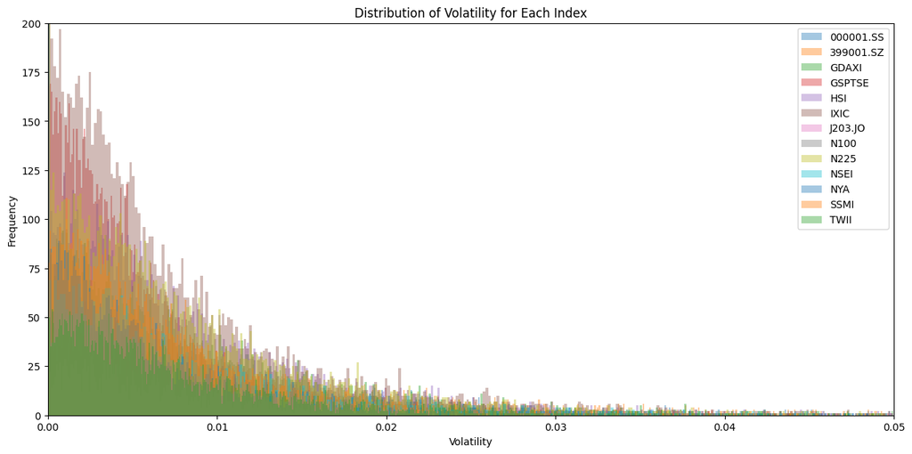

```python
# distribution of volatility for each index
plt.figure(figsize=(15, 7))
# only x values from 0 to 0.1
plt.xlim(0, 0.05)
plt.ylim(0, 200)
for index in data['Index'].unique():
    plt.hist(data[data['Index'] == index]['Volatility'], bins=1000, alpha=0.4, label=index)
plt.legend(loc='upper right')
plt.title('Distribution of Volatility for Each Index')
plt.xlabel('Volatility')
plt.ylabel('Frequency')
plt.show()
```

The distributions for each value do not appear normal (exponential) so we need to account for this when running statistical tests.

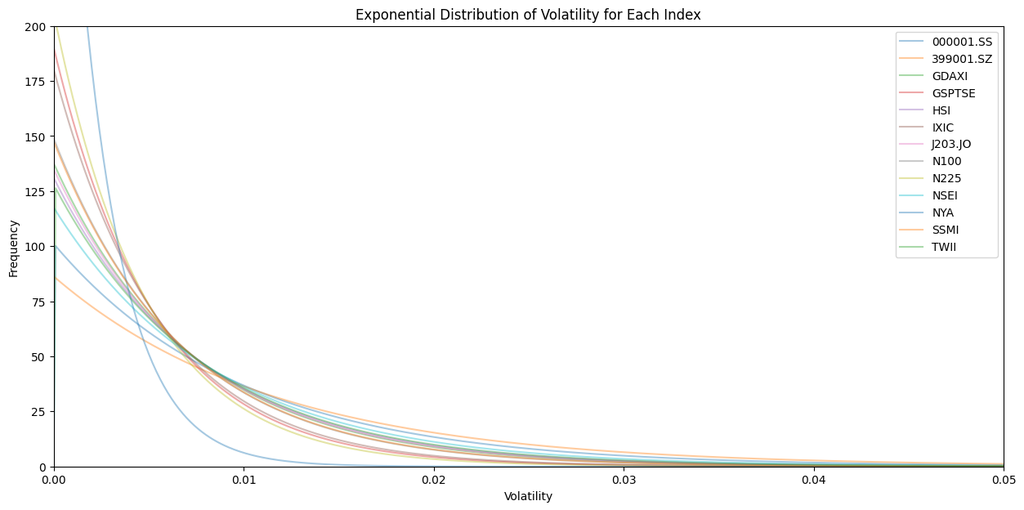

```python
import scipy.stats as stats
import math

# fit the data to an exponential distribution
plt.figure(figsize=(15, 7))
plt.xlim(0, 0.05)
plt.ylim(0, 200)
for index in data['Index'].unique():
    # fit the data to an exponential distribution
    params = stats.expon.fit(data[data['Index'] == index]['Volatility'])
    x = np.linspace(0, 0.1, 1000)
    y = stats.expon.pdf(x, *params)
    plt.plot(x, y, alpha = 0.4, label=index)
plt.legend(loc='upper right')
plt.title('Exponential Distribution of Volatility for Each Index')
plt.xlabel('Volatility')
plt.ylabel('Frequency')
plt.show()
```

The test best suited for populations matching that of an exponential distribution is the Kolmogorov-Smirnov Test which compares the cumulative distribution functions (CDFs) of the two samples to determine if they likely come from the same distribution. It's a non-parametric test and is suitable for comparing distributions when you have limited information about the underlying distributions.

```python
# Kolmogorov-Smirnov Test
from scipy.stats import ks_2samp

# Assuming you have two Pandas Series or DataFrames: data1 and data2
# Replace data1 and data2 with your actual data
# For example:
# data1 = pd.Series(...)
# data2 = pd.Series(...)

data1 = data[data['Index'] == 'HSI']['Volatility']
data2 = data[data['Index'] == 'TWII']['Volatility']

# Perform the Kolmogorov-Smirnov test
ks_statistic, p_value = ks_2samp(data1, data2)

# Output the results
print("Kolmogorov-Smirnov statistic:", ks_statistic)
print("p-value:", p_value)
```

```
Kolmogorov-Smirnov statistic: 0.0684173339613754
p-value: 1.429197806316901e-14
```

Now lets compare all of the possible combinations of indices to see if any have a p-value > alpha = 0.05.

The null hypothesis is that there is no significant difference between the various indices and their volatility distributions. The alternate hypothesis is that there is a significant difference between the various indices and their volatility distributions.

```python
# Now lets compare all of the possible combinations of indeces to see if any have a p-value > aplha = 0.05.
# We will store the results in a dictionary for easy access later.

# Create a dictionary to store the results
results = {}

# Get a list of all the indeces
indeces = data['Index'].unique()

# Loop through all the possible combinations of indeces
for i in range(len(indeces)):
    for j in range(i+1, len(indeces)):
        # Get the names of the two indeces
        index1 = indeces[i]
        index2 = indeces[j]
        # Get the data for the two indeces
        data1 = data[data['Index'] == index1]['Volatility']
        data2 = data[data['Index'] == index2]['Volatility']
        # Perform the Kolmogorov-Smirnov test
        ks_statistic, p_value = ks_2samp(data1, data2)
        # Store the results in the dictionary
        results[(index1, index2)] = (ks_statistic, p_value)

# Output the results
for key, value in results.items():
    print(key, value)

# Now we can see that the p-value for the combination of indeces ('HSI', 'TWII') is 0.0, which is less than alpha = 0.05.
# This means that we can reject the null hypothesis that the two distributions are the same.
# This is interesting because the Hang Seng Index (HSI) is the main index for the Hong Kong stock market, and the Taiwan Weighted Index (TWII) is the main index for the Taiwan stock market.
```

```
('000001.SS', '399001.SZ') (0.0817010411270362, 3.2117730769702507e-17)
('000001.SS', 'GDAXI') (0.17761918079598876, 4.259597970263839e-95)
('000001.SS', 'GSPTSE') (0.24678974525685438, 6.82951369846827e-201)
('000001.SS', 'HSI') (0.09404042184450948, 6.033406959496413e-27)
('000001.SS', 'IXIC') (0.2785662352888827, 2.63655545534768e-273)
('000001.SS', 'J203.JO') (0.10406401266745013, 3.396134708309584e-16)
('000001.SS', 'N100') (0.14786873057842959, 4.0452265771495617e-54)
('000001.SS', 'N225') (0.4132910480034597, 0.0)
('000001.SS', 'NSEI') (0.08275171512817, 4.402046630453707e-13)
('000001.SS', 'NYA') (0.6681006668100666, 0.0)
('000001.SS', 'SSMI') (0.1401343333882376, 6.019786703260684e-57)
('000001.SS', 'TWII') (0.09448083654817867, 4.2611380841968e-23)
('399001.SZ', 'GDAXI') (0.21136689842248033, 2.3621161879252194e-134)
('399001.SZ', 'GSPTSE') (0.3250920340110203, 0.0)
('399001.SZ', 'HSI') (0.17139758988852252, 1.693913652262446e-88)
('399001.SZ', 'IXIC') (0.32239460204885734, 0.0)
('399001.SZ', 'J203.JO') (0.1711881038647343, 3.893557146918449e-43)
('399001.SZ', 'N100') (0.22379474434701416, 1.2138596860262442e-123)
('399001.SZ', 'N225') (0.4113865313616196, 0.0)
('399001.SZ', 'NSEI') (0.16112045062097363, 2.0399289895660617e-48)
('399001.SZ', 'NYA') (0.6659154223727922, 0.0)
('399001.SZ', 'SSMI') (0.21343527299787077, 1.1108308490873894e-131)
('399001.SZ', 'TWII') (0.1709518941330153, 1.2071814864440512e-74)
('GDAXI', 'GSPTSE') (0.17313561241395192, 2.9814244243179144e-123)
('GDAXI', 'HSI') (0.10834058004427183, 1.0531748846262843e-43)
('GDAXI', 'IXIC') (0.11283947379775272, 1.1517549567584349e-56)
('GDAXI', 'J203.JO') (0.1654554852434497, 2.3890536373133664e-44)
('GDAXI', 'N100') (0.11268802171362687, 3.6487818538274234e-37)
('GDAXI', 'N225') (0.2367809968038285, 2.775277674535863e-259)
('GDAXI', 'NSEI') (0.17610291133087488, 2.2193953242341476e-65)
('GDAXI', 'NYA') (0.4917117153953953, 0.0)
('GDAXI', 'SSMI') (0.17536148014570163, 2.2733167801490105e-108)
('GDAXI', 'TWII') (0.17658212846646124, 9.879433940742182e-95)
('GSPTSE', 'HSI') (0.15502995118115437, 4.100490479350035e-99)
('GSPTSE', 'IXIC') (0.2740726666244432, 0.0)
('GSPTSE', 'J203.JO') (0.17321886664272562, 8.53076652404806e-51)
('GSPTSE', 'N100') (0.10620055174545262, 8.062424962500216e-36)
('GSPTSE', 'N225') (0.4097300913837852, 0.0)
('GSPTSE', 'NSEI') (0.16850916167054641, 1.7160951511781332e-63)
('GSPTSE', 'NYA') (0.6646106556782421, 0.0)
```

[output cut: 23 more lines]

```
('N100', 'N225') (0.3490926928398701, 0.0)
('N100', 'NSEI') (0.09871618285298475, 4.572854685026624e-18)
('N100', 'NYA') (0.6041159026293469, 0.0)
('N100', 'SSMI') (0.06458232746432133, 4.975570768866983e-12)
('N100', 'TWII') (0.08688097758308877, 4.732864262579926e-19)
('N225', 'NSEI') (0.4127653966390883, 0.0)
('N225', 'NYA') (0.25530736900053647, 0.0)
('N225', 'SSMI') (0.4119874370009829, 0.0)
('N225', 'TWII') (0.4132910480034597, 0.0)
('NSEI', 'NYA') (0.6675746381860352, 0.0)
('NSEI', 'SSMI') (0.06868389755222684, 5.284399625046924e-10)
('NSEI', 'TWII') (0.020724246669946756, 0.31384899483199097)
('NYA', 'SSMI') (0.6668361725498668, 0.0)
('NYA', 'TWII') (0.6681006668100666, 0.0)
('SSMI', 'TWII') (0.05504172610268799, 3.3632598176701046e-09)
```

Let us see the ones that might have not have a significant difference in their distributions.

```python
for key, value in results.items():
    if value[1] > 0.05:
        print(key, value)
```

```
('J203.JO', 'TWII') (0.030284107242280558, 0.09014935779994619)
('NSEI', 'TWII') (0.020724246669946756, 0.31384899483199097)
```

Lets see what these volatility graphs look like next to each other.

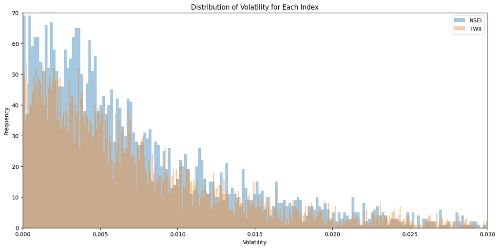

```python
# distribution of volatility for each index
plt.figure(figsize=(15, 7))
# only x values from 0 to 0.1
plt.xlim(0, 0.03)
plt.ylim(0, 70)
plt.hist(data[data['Index'] == 'NSEI']['Volatility'], bins=1000, alpha=0.4, label='NSEI')
plt.hist(data[data['Index'] == 'TWII']['Volatility'], bins=1000, alpha=0.4, label='TWII')
plt.legend(loc='upper right')
plt.title('Distribution of Volatility for Each Index')
plt.xlabel('Volatility')
plt.ylabel('Frequency')
plt.show()
```

Thus here we can see that the p-value for most of the possible comparisons of the indeces are less than alpha such that they are all significantly different. Thus from the distributions we can see the most "stable" index is the NYA index, and the most "volatile" is the 399001.SZ index.

There are some that are similar and this means they are not significantly different enough to compare their volatility means.

### Part 2 (b): Change Analysis - Distributions

This is to see what the data looks like and what tickers we have. It also finds the mean change value for each ticker and we can then perform an analysis to see the effect ticker label has on the mean change which may tell us which companies lose/grow more daily in terms of percentage.

```python
data.groupby('Index')['Change'].mean()
```

```
Index
000001.SS    0.000739
399001.SZ    0.000657
GDAXI       -0.000042
GSPTSE       0.000020
HSI         -0.000092
IXIC         0.000064
J203.JO      0.000344
N100        -0.000110
N225        -0.000155
NSEI        -0.000560
NYA          0.000070
SSMI         0.000099
TWII        -0.001080
Name: Change, dtype: float64
```

Then before we run an analysis let us see what the data looks like in terms of change for each index.

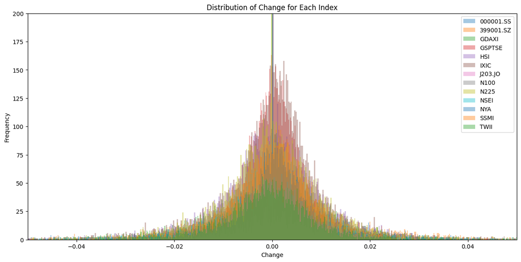

```python
# distribution of volatility for each index
plt.figure(figsize=(15, 7))
# only x values from 0 to 0.1
plt.xlim(-0.05, 0.05)
plt.ylim(0, 200)
for index in data['Index'].unique():
    plt.hist(data[data['Index'] == index]['Change'], bins=1000, alpha=0.4, label=index)
plt.legend(loc='upper right')
plt.title('Distribution of Change for Each Index')
plt.xlabel('Change')
plt.ylabel('Frequency')
plt.show()
```

This data looks normal so let us run a simply ANOVA to see if there is a significant difference in the mean change across any of the indices to see if any performed on average any better than other indices.

```python
# ANOVA Test for all indeces to see if there is a significant difference in the mean change between the indeces.
from scipy.stats import f_oneway

# Create a list to store the data for each index
data_list = []

# Loop through all the indeces
for index in data['Index'].unique():
    # Get the data for the index
    data_list.append(data[data['Index'] == index]['Change'])

# Perform the ANOVA test
f_statistic, p_value = f_oneway(*data_list)

# Output the results
print("F-statistic:", f_statistic)
print("p-value:", p_value)
```

```
F-statistic: 11.004025619546464
p-value: 2.480682554764391e-22
```

This p-value is less than alpha = 0.05 so we know that there is a significant difference in means, this means it is worth doing Post-hoc tests to see which ones are significantly different. In this case we will use the tukey test.

```python
# tukey's range test
from statsmodels.stats.multicomp import pairwise_tukeyhsd

# Perform Tukey's range test on each combination of indeces from the ANOVA test on data_list = []
tukey_results = pairwise_tukeyhsd(data['Change'], data['Index'])

# Output the results
print(tukey_results)
```

```
   Multiple Comparison of Means - Tukey HSD, FWER=0.05
==========================================================
  group1    group2  meandiff p-adj   lower   upper  reject
----------------------------------------------------------
000001.SS 399001.SZ  -0.0001    1.0 -0.0007  0.0006  False
000001.SS     GDAXI  -0.0008 0.0009 -0.0014 -0.0002   True
000001.SS    GSPTSE  -0.0007 0.0019 -0.0013 -0.0002   True
000001.SS       HSI  -0.0008 0.0002 -0.0014 -0.0002   True
000001.SS      IXIC  -0.0007 0.0033 -0.0012 -0.0001   True
000001.SS   J203.JO  -0.0004 0.9469 -0.0012  0.0005  False
000001.SS      N100  -0.0008 0.0012 -0.0015 -0.0002   True
000001.SS      N225  -0.0009    0.0 -0.0014 -0.0004   True
000001.SS      NSEI  -0.0013    0.0 -0.0021 -0.0005   True
000001.SS       NYA  -0.0007  0.003 -0.0012 -0.0001   True
000001.SS      SSMI  -0.0006 0.0263 -0.0012    -0.0   True
000001.SS      TWII  -0.0018    0.0 -0.0025 -0.0012   True
399001.SZ     GDAXI  -0.0007 0.0062 -0.0013 -0.0001   True
399001.SZ    GSPTSE  -0.0006  0.013 -0.0012 -0.0001   True
399001.SZ       HSI  -0.0007  0.002 -0.0013 -0.0002   True
399001.SZ      IXIC  -0.0006 0.0219 -0.0011    -0.0   True
399001.SZ   J203.JO  -0.0003 0.9921 -0.0012  0.0005  False
399001.SZ      N100  -0.0008 0.0069 -0.0014 -0.0001   True
399001.SZ      N225  -0.0008 0.0001 -0.0014 -0.0003   True
399001.SZ      NSEI  -0.0012    0.0  -0.002 -0.0005   True
399001.SZ       NYA  -0.0006  0.021 -0.0011    -0.0   True
399001.SZ      SSMI  -0.0006 0.1062 -0.0012     0.0  False
399001.SZ      TWII  -0.0017    0.0 -0.0024 -0.0011   True
    GDAXI    GSPTSE   0.0001    1.0 -0.0004  0.0006  False
    GDAXI       HSI     -0.0    1.0 -0.0006  0.0005  False
    GDAXI      IXIC   0.0001    1.0 -0.0004  0.0006  False
    GDAXI   J203.JO   0.0004 0.9366 -0.0004  0.0012  False
    GDAXI      N100  -0.0001    1.0 -0.0007  0.0005  False
    GDAXI      N225  -0.0001 0.9999 -0.0006  0.0004  False
    GDAXI      NSEI  -0.0005 0.4331 -0.0012  0.0002  False
    GDAXI       NYA   0.0001 0.9999 -0.0004  0.0006  False
    GDAXI      SSMI   0.0001 0.9998 -0.0004  0.0007  False
    GDAXI      TWII   -0.001    0.0 -0.0016 -0.0004   True
   GSPTSE       HSI  -0.0001    1.0 -0.0006  0.0004  False
   GSPTSE      IXIC      0.0    1.0 -0.0004  0.0005  False
   GSPTSE   J203.JO   0.0003 0.9805 -0.0005  0.0011  False
```

[output cut: 28 more lines]

```
     N100      NSEI  -0.0004 0.7629 -0.0012  0.0003  False
     N100       NYA   0.0002 0.9975 -0.0004  0.0007  False
     N100      SSMI   0.0002 0.9962 -0.0004  0.0008  False
     N100      TWII   -0.001 0.0001 -0.0016 -0.0003   True
     N225      NSEI  -0.0004 0.7314 -0.0011  0.0003  False
     N225       NYA   0.0002 0.8539 -0.0002  0.0006  False
     N225      SSMI   0.0003 0.8939 -0.0002  0.0007  False
     N225      TWII  -0.0009    0.0 -0.0015 -0.0004   True
     NSEI       NYA   0.0006 0.0885    -0.0  0.0013  False
     NSEI      SSMI   0.0007 0.1131 -0.0001  0.0014  False
     NSEI      TWII  -0.0005 0.5224 -0.0013  0.0002  False
      NYA      SSMI      0.0    1.0 -0.0005  0.0005  False
      NYA      TWII  -0.0012    0.0 -0.0017 -0.0006   True
     SSMI      TWII  -0.0012    0.0 -0.0018 -0.0006   True
----------------------------------------------------------
```

The index with the highest mean growth per day and a significant difference between most of the indices was the "000001.SS" index, so lets plot it to see what this growth looks like. Also a takeaway as an investor from this test might be to invest in this stock if you plan to day trade.

This stock is not significantly different than some stocks so the best way to go about this would be to group stocks by their mean change and the group would consist of those that are not significantly different.

The graph below is the plot of the stock with the highest rate of positive change (positive so it is growth).

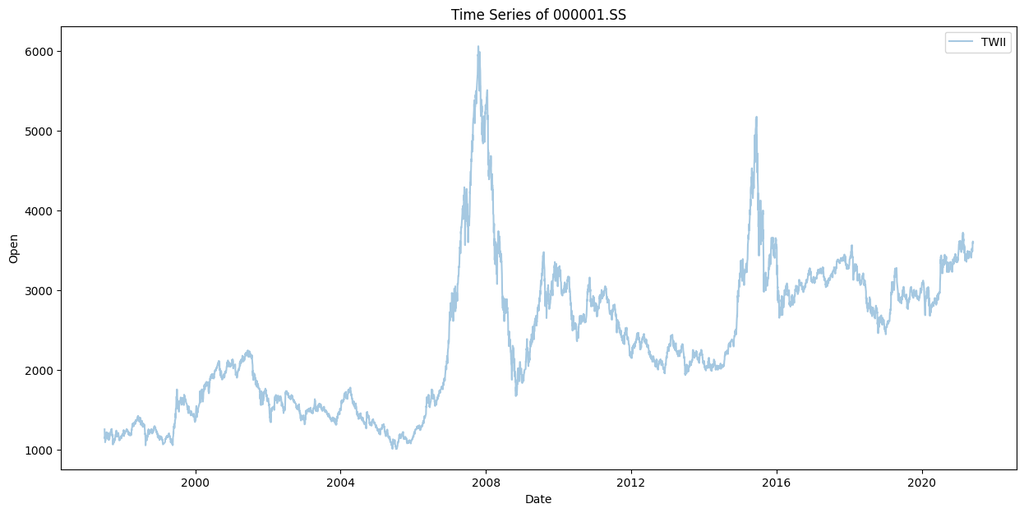

```python
# time series analysis of the indices on the same plot
plt.figure(figsize=(15, 7))
plt.plot(data[data['Index'] == '000001.SS']['Date'], data[data['Index'] == '000001.SS']['Open'], alpha=0.4, label=index)
plt.legend(loc='upper right')
plt.title('Time Series of 000001.SS')
plt.xlabel('Date')
plt.ylabel('Open')
plt.show()
```

### Part 3: Autocorrelation Analysis - Time-Series

Stock data is usually time series based and so it wouldn't be a good analysis without looking at the plot over time of this data as well as running time series based statistical tests.

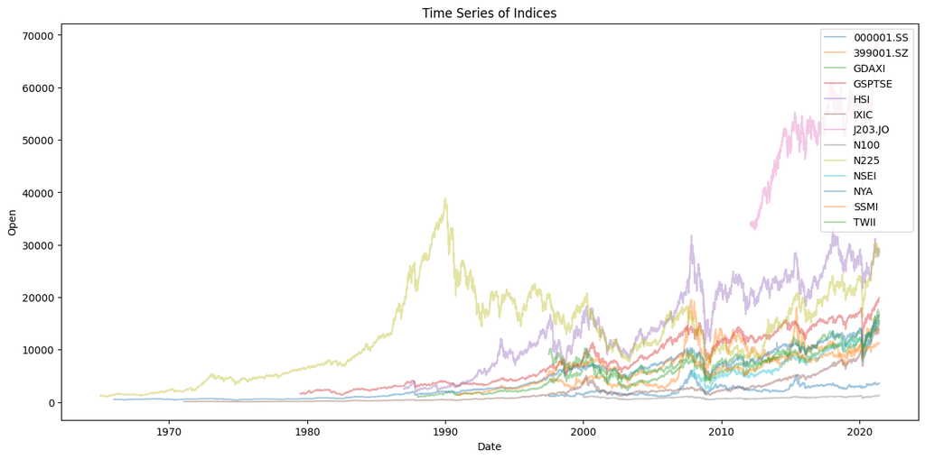

```python
# time series analysis of the indices on the same plot
plt.figure(figsize=(15, 7))
for index in data['Index'].unique():
    plt.plot(data[data['Index'] == index]['Date'], data[data['Index'] == index]['Open'], alpha=0.4, label=index)
plt.legend(loc='upper right')
plt.title('Time Series of Indices')
plt.xlabel('Date')
plt.ylabel('Open')
plt.show()
```

The autocorrelation function (ACF) is a statistical tool used to identify patterns or relationships within a time series data set. It measures the correlation between a series and its own lagged values at different time intervals. In simpler terms, it tells you how correlated a data point is with its past values. Let us run this to see how our data works for this.

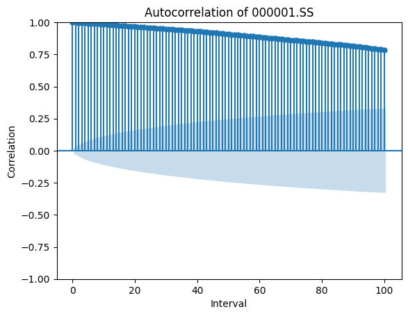

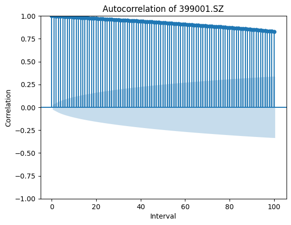

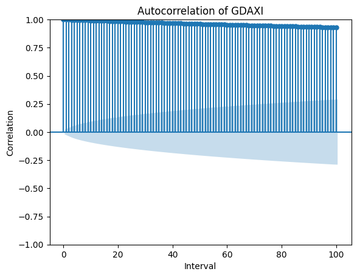

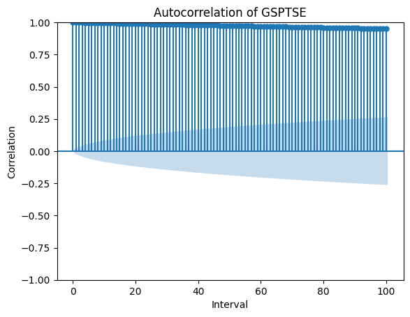

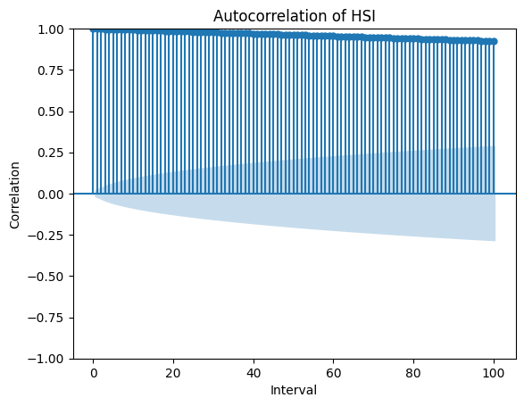

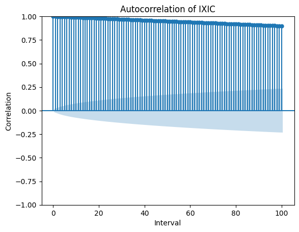

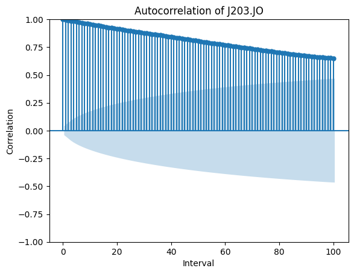

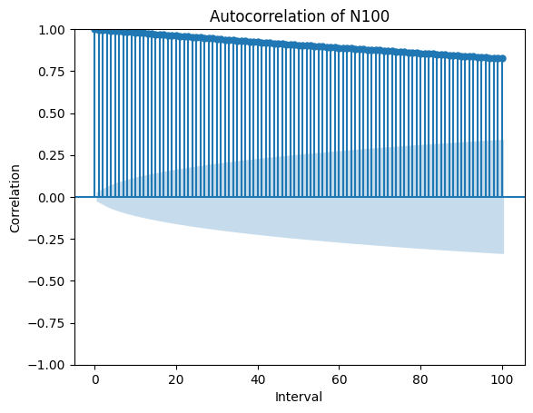

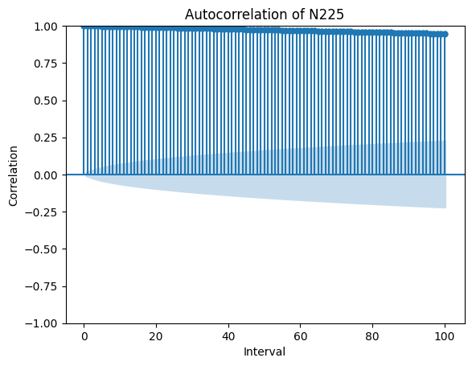

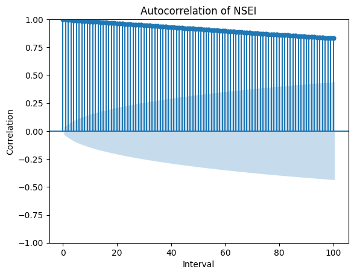

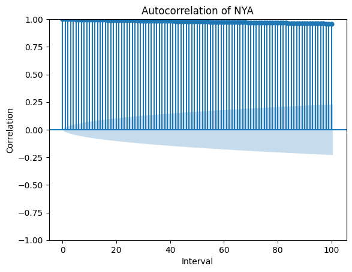

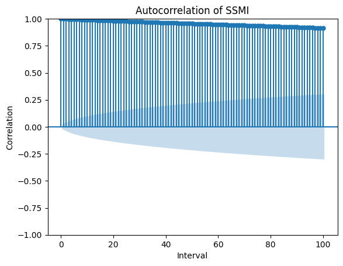

[1 more figures not shown]

```python
from statsmodels.graphics.tsaplots import plot_acf, plot_pacf
for index in data['Index'].unique():
    plot_acf(data[data['Index'] == index]['Open'].dropna(), lags=100)
    plt.title('Autocorrelation of ' + index)
    plt.xlabel('Interval')
    plt.ylabel('Correlation')
    plt.show()
    '''
    plot_pacf(data[data['Index'] == index]['Open'].dropna(), lags=100)
    plt.title('Autocorrelation of ' + index)
    plt.xlabel('Interval')
    plt.ylabel('Correlation')
    plt.show()
    '''
```

The plots above show a very high autocorrelation between lagged values and the current value and it suggests a strong correlation between the observations at various lags. There are definitely differences within the various indices but most of them are fairly high. The one that stays very high is the NYA index and the one with the least correlation between later values is J203.JO with a higher rate of decay.

Let us see these autocorrelation values under a difference level to see how it performs when it is stationary. Lets check if the data is stationary at the moment first.

```python
from statsmodels.tsa.stattools import adfuller

for index in data['Index'].unique():
    adf_test = adfuller(data[data['Index'] == index]['Open'])
    # Output the results
    print(index, ':',  ' ADF Statistic: %f' % adf_test[0], ':', ' p-value: %f' % adf_test[1])
```

```
000001.SS :  ADF Statistic: -2.121624 :  p-value: 0.235909
399001.SZ :  ADF Statistic: -1.605774 :  p-value: 0.480693
GDAXI :  ADF Statistic: 0.040838 :  p-value: 0.961782
GSPTSE :  ADF Statistic: -0.018703 :  p-value: 0.956958
HSI :  ADF Statistic: -1.302970 :  p-value: 0.627812
IXIC :  ADF Statistic: 5.074546 :  p-value: 1.000000
J203.JO :  ADF Statistic: -1.551575 :  p-value: 0.507861
N100 :  ADF Statistic: -1.362484 :  p-value: 0.600124
N225 :  ADF Statistic: -1.176347 :  p-value: 0.683687
NSEI :  ADF Statistic: 0.557778 :  p-value: 0.986527
NYA :  ADF Statistic: 1.277973 :  p-value: 0.996483
SSMI :  ADF Statistic: -1.307084 :  p-value: 0.625925
TWII :  ADF Statistic: 0.197821 :  p-value: 0.972139
```

This data clearly is not stationary with extremely high p-values all above 0.05. This means we have to clean the data before performing our ARIMA on the data. We can do this with differencing so that the data has a constant mean.

```python
series_list = []
for index in data['Index'].unique():
  series_list.append(None)
  series = data[data['Index'] == index]['Open']

  # Iterate through the series
  for i in range(1, len(series)):
    previous_value = series.values[i-1]
    current_value = series.values[i]
    difference = current_value - previous_value
    series_list.append(difference)

# Add the list of differences to the DataFrame
series_insert = pd.Series(series_list)
print(series_insert.mean())
print(data['Open'].mean())
data['Difference'] = series_insert
```

```
1.847643483307904
8015.353333862555
```

Let us see the graph of these values after we differenced the data.

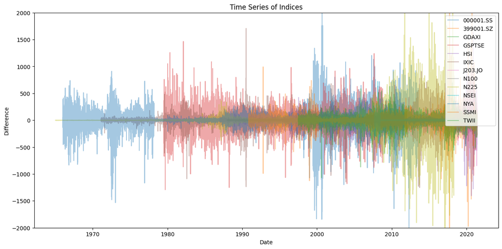

```python
plt.figure(figsize=(15, 7))
plt.ylim(-2000, 2000)
for index in data['Index'].unique():
    plt.plot(data[data['Index'] == index]['Date'], data[data['Index'] == index]['Difference'], alpha=0.4, label=index)
plt.legend(loc='upper right')
plt.title('Time Series of Indices')
plt.xlabel('Date')
plt.ylabel('Difference')
plt.show()
```

Lets run the stationary test on this data now.

```python
from statsmodels.tsa.stattools import adfuller

for index in data['Index'].unique():
    adf_test = adfuller((data[data['Index'] == index]['Difference']).dropna())
    # Output the results
    print(index, ':',  ' ADF Statistic: %f' % adf_test[0], ':', ' p-value: %f' % adf_test[1])
```

```
000001.SS :  ADF Statistic: -15.835401 :  p-value: 0.000000
399001.SZ :  ADF Statistic: -11.155598 :  p-value: 0.000000
GDAXI :  ADF Statistic: -16.319758 :  p-value: 0.000000
GSPTSE :  ADF Statistic: -99.863800 :  p-value: 0.000000
HSI :  ADF Statistic: -13.000268 :  p-value: 0.000000
IXIC :  ADF Statistic: -17.605161 :  p-value: 0.000000
J203.JO :  ADF Statistic: -23.029864 :  p-value: 0.000000
N100 :  ADF Statistic: -37.010402 :  p-value: 0.000000
N225 :  ADF Statistic: -19.239316 :  p-value: 0.000000
NSEI :  ADF Statistic: -6.531392 :  p-value: 0.000000
NYA :  ADF Statistic: -17.448834 :  p-value: 0.000000
SSMI :  ADF Statistic: -25.314703 :  p-value: 0.000000
TWII :  ADF Statistic: -38.738311 :  p-value: 0.000000
```

The data is now stationary so we can now run the autocorrelation test on the data to find any potential patterns in lag correlation beyond the first difference.

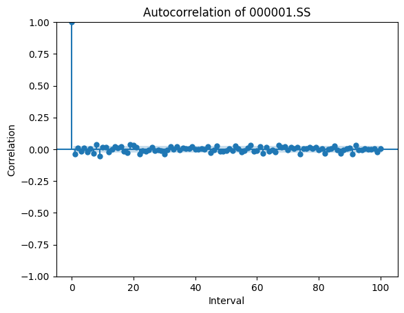

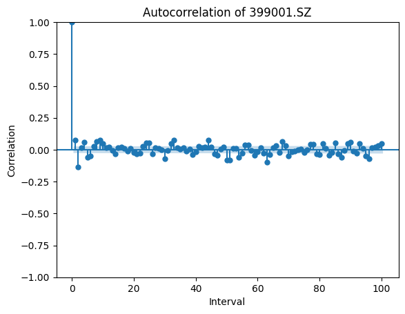

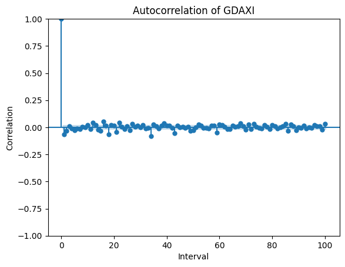

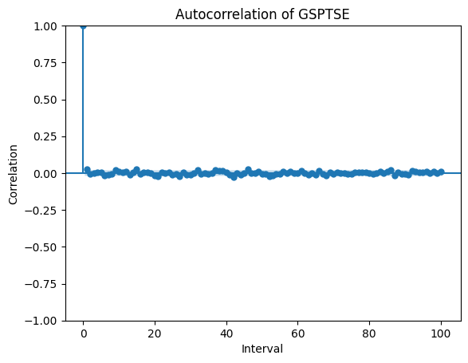

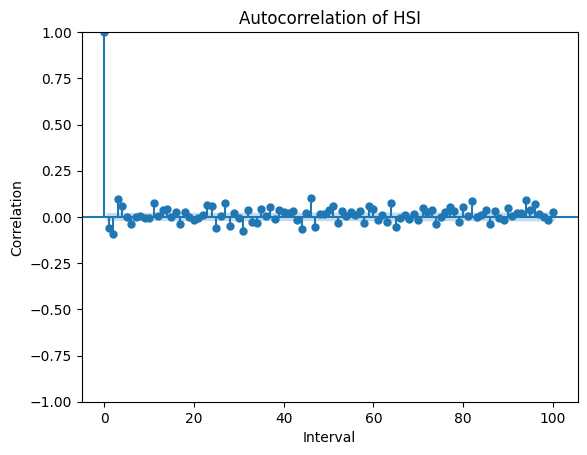

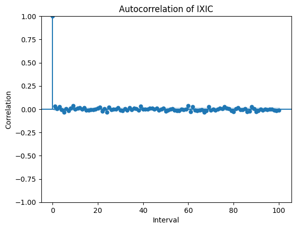

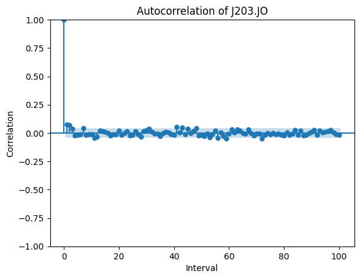

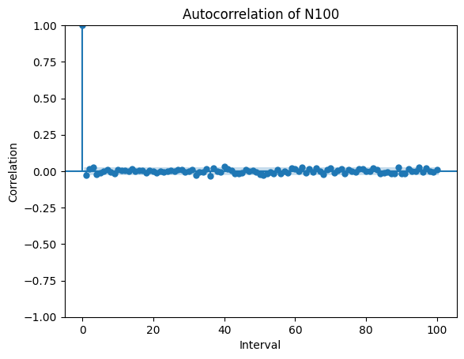

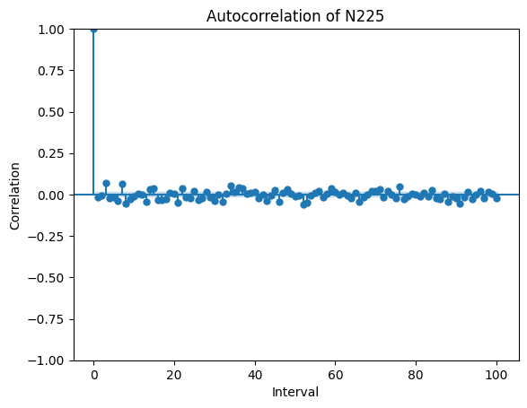

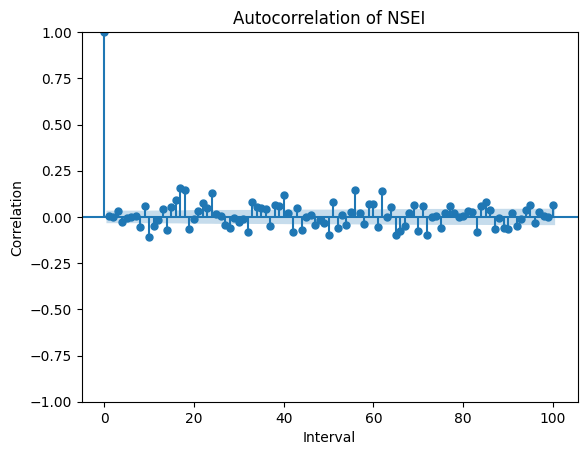

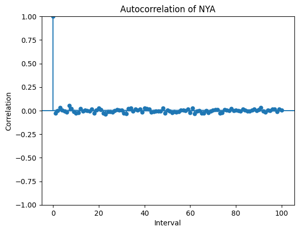

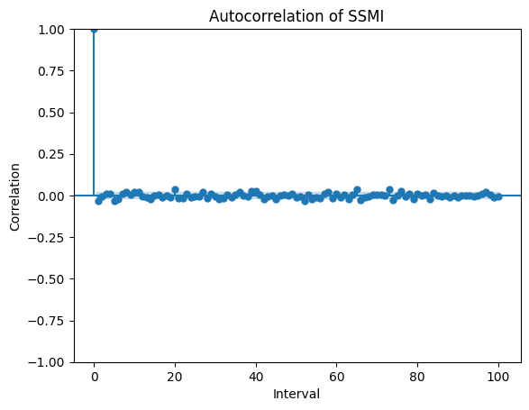

[1 more figures not shown]

```python
from statsmodels.graphics.tsaplots import plot_acf, plot_pacf
for index in data['Index'].unique():
    plot_acf(data[data['Index'] == index]['Difference'].dropna(), lags=100)
    plt.title('Autocorrelation of ' + index)
    plt.xlabel('Interval')
    plt.ylabel('Correlation')
    plt.show()
```

This means that the data after one difference does not have too much autocorrelation and some stocks such as NSEI have more correlation between the difference than something like TWII. This statistical analysis also helps with the machine learning model I plan to use later (ARIMA).

### Part 4: Cointegration Analysis - Time-Series

Cointegration is a statistical concept when n time series are individually non-stationary but a linear combination of them is stationary. It suggests that although the individual series may be trending over time, there exists a long-term equilibrium relationship between them. Cointegration is useful since it implies that certain stocks move together in the long run despite short-term fluctuations.

In this code we just check two random indices to see if this cointegration code works to analyze the correlation between two indexes.

```python
from statsmodels.tsa.stattools import adfuller
from statsmodels.regression.linear_model import OLS

# Choose the indices for testing cointegration
index1 = 'HSI'
index2 = 'TWII'

# Extract the corresponding data
data_index1 = (data[data['Index'] == index1]['Open']).dropna()
data_index2 = (data[data['Index'] == index2]['Open']).dropna()

# Step 2: Find cointegration relationship
# Perform OLS regression
X = data_index1.values.reshape(-1, 1)
y = data_index2.values
min_length = min(len(y), len(X))
y = y[:min_length]
X = X[:min_length]
X = np.concatenate((np.ones((len(X), 1)), X), axis=1)  # Add intercept term
model = OLS(y, X)
result = model.fit()

# Extract the cointegrating vector
cointegrating_vector = result.params[1]

print("Cointegrating Vector (Coefficient):", cointegrating_vector)
```

```
Cointegrating Vector (Coefficient): 0.24726452138099025
```

In this code we just check all two index combinations to see the cointegration values and to analyze the correlation between the many indexes.

```python
from statsmodels.tsa.stattools import adfuller
from statsmodels.regression.linear_model import OLS

# Now we can test for cointegration between all the possible combinations of indeces.
# We will store the results in a dictionary for easy access later.

# Create a dictionary to store the results
cointegration_results = {}

# Get a list of all the indeces
indeces = data['Index'].unique()

# Loop through all the possible combinations of indeces
for i in range(len(indeces)):
    for j in range(i+1, len(indeces)):
        # Get the names of the two indeces
        index1 = indeces[i]
        index2 = indeces[j]
        # Extract the corresponding data
        data_index1 = (data[data['Index'] == index1]['Open']).dropna()
        data_index2 = (data[data['Index'] == index2]['Open']).dropna()
        # Perform OLS regression
        X = data_index1.values.reshape(-1, 1)
        y = data_index2.values
        min_length = min(len(y), len(X))
        y = y[:min_length]
        X = X[:min_length]
        X = np.concatenate((np.ones((len(X), 1)), X), axis=1)  # Add intercept term
        model = OLS(y, X)
        result = model.fit()
        # Extract the cointegrating vector
        cointegrating_vector = result.params[1]
        # Store the results in the dictionary
        cointegration_results[(index1, index2)] = cointegrating_vector

# Output the results
for key, value in cointegration_results.items():
    print(key, value)
```

```
('000001.SS', '399001.SZ') 3.9364804856532176
('000001.SS', 'GDAXI') 1.549642769660273
('000001.SS', 'GSPTSE') 1.2846770494028585
('000001.SS', 'HSI') 4.257743666634351
('000001.SS', 'IXIC') 0.10973949582790542
('000001.SS', 'J203.JO') 9.698904631042314
('000001.SS', 'N100') -0.00934328728810681
('000001.SS', 'N225') 3.185493749239234
('000001.SS', 'NSEI') 1.8435768877129972
('000001.SS', 'NYA') 0.17477875723424774
('000001.SS', 'SSMI') 1.2543909901842218
('000001.SS', 'TWII') 1.2409929770638943
('399001.SZ', 'GDAXI') 0.3914704502027085
('399001.SZ', 'GSPTSE') 0.28809047257154285
('399001.SZ', 'HSI') 1.0205738128020319
('399001.SZ', 'IXIC') 0.028050883320381644
('399001.SZ', 'J203.JO') 1.6660330558783631
('399001.SZ', 'N100') -0.0016160357537060113
('399001.SZ', 'N225') 0.7964524393743484
('399001.SZ', 'NSEI') 0.5173639704875147
('399001.SZ', 'NYA') 0.038557179630510606
('399001.SZ', 'SSMI') 0.31507971270571805
('399001.SZ', 'TWII') 0.2908806528100947
('GDAXI', 'GSPTSE') 0.9236852233731012
('GDAXI', 'HSI') 1.998003822705739
('GDAXI', 'IXIC') 0.19891941808939193
('GDAXI', 'J203.JO') 12.21184354953412
('GDAXI', 'N100') 0.014706819151589745
('GDAXI', 'N225') 1.6578980657192803
('GDAXI', 'NSEI') 1.3342791054206977
('GDAXI', 'NYA') 0.34285837242815836
('GDAXI', 'SSMI') 0.57579404986827
('GDAXI', 'TWII') 0.662747065232217
('GSPTSE', 'HSI') 1.9071121453194044
('GSPTSE', 'IXIC') 0.18144163422149853
('GSPTSE', 'J203.JO') 7.166345622021116
('GSPTSE', 'N100') 0.05139713613940824
('GSPTSE', 'N225') 0.9843153442662887
('GSPTSE', 'NSEI') 3.098017221746998
('GSPTSE', 'NYA') 0.47130635563247913
```

[output cut: 23 more lines]

```
('N100', 'N225') 12.959620605798618
('N100', 'NSEI') -4.79955492227355
('N100', 'NYA') 1.066918393289021
('N100', 'SSMI') 2.374621723430934
('N100', 'TWII') 4.496879139860395
('N225', 'NSEI') 1.6829846157941148
('N225', 'NYA') 0.23043811602746408
('N225', 'SSMI') 0.17343842074046106
('N225', 'TWII') 0.2806502554888487
('NSEI', 'NYA') 0.0037859928453549334
('NSEI', 'SSMI') 0.5627560079254358
('NSEI', 'TWII') 0.10648743135311418
('NYA', 'SSMI') 2.012672014407448
('NYA', 'TWII') 4.541876772159551
('SSMI', 'TWII') 0.40997672200233315
```

```python
for key, value in cointegration_results.items():
    if abs(value) > 10:
        print(key, value)
```

```
('GDAXI', 'J203.JO') 12.21184354953412
('IXIC', 'NSEI') 36.88770670567579
('N100', 'N225') 12.959620605798618
```

The tests from above are the ones with the highest correlations and this means there may be at least a little bit of potential correlation between the sets of two.

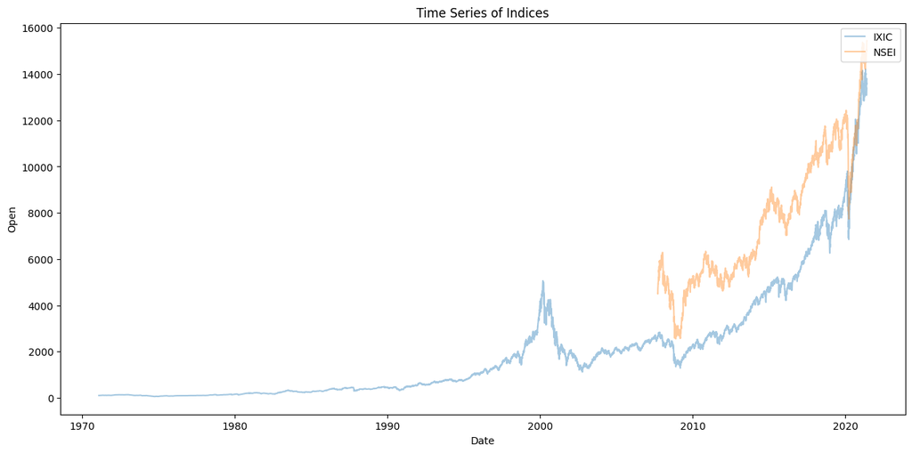

```python
# time series analysis of the indices on the same plot
plt.figure(figsize=(15, 7))
plt.plot(data[data['Index'] == 'IXIC']['Date'], data[data['Index'] == 'IXIC']['Open'], alpha=0.4, label='IXIC')
plt.plot(data[data['Index'] == 'NSEI']['Date'], data[data['Index'] == 'NSEI']['Open'], alpha=0.4, label='NSEI')
plt.legend(loc='upper right')
plt.title('Time Series of Indices')
plt.xlabel('Date')
plt.ylabel('Open')
plt.show()
```

This cointegration correlation test helps us find patterns in the world that stocks may share helping us predict other stocks from one known stock.

### Part 5: Machine Learning

The objective is to develop a model that can accurately predict whether the subsequent value will exhibit an increase or decrease compared to the current value. The input to the model will consist of an array of historical index values, and the minimum acceptable accuracy threshold is set at 50%, considering the binary nature of the prediction task (the value can only move in two possible directions: up or down).

The sequential nature of time series data and the need to capture long-term dependencies, the Long Short-Term Memory (LSTM) model is a good choice for this use case. LSTMs are a specific type of recurrent neural network (RNN) architecture that has proven effective in handling time series forecasting tasks. They are designed to address the vanishing gradient problem often encountered in traditional RNNs, enabling the model to retain and utilize information from longer sequences.

Lets begin using a pytorch LSTM model and making the data an array.